# Проект: телекоммуникации

### Проверка на адекватность

На всякий случай проверим найденные модели на адекватность с помощью dummy-классификатора. Инициализируем параметры и найдем лучшую модель (вернее, лучшую стратегию предсказаний).

```python
dummy_clf_pipe = Pipeline(
    [
        ('prep', dataprep),
        ('model', DummyClassifier())
    ]
)

dummy_clf_params = [
    {
        'model': [DummyClassifier()],
        'model__strategy': ['most_frequent',
                            'prior',
                            'stratified',
                            'uniform',
                           ],
        'prep__num': [StandardScaler(),
                      MinMaxScaler(),
                      RobustScaler(),
                      'passthrough'
                     ]
    },
    {
        'model': [DummyClassifier()],
        'model__strategy': ['constant'],
        'model__constant': [i for i in range(0, 2)],
        'prep__num': [StandardScaler(),
                      MinMaxScaler(),
                      RobustScaler(),
                      'passthrough'
                     ]
    }
]

dummy_clf_grid = GridSearchCV(pipe_model,
                              param_grid=dummy_clf_params,
                              cv=5,
                              scoring='roc_auc',
                              n_jobs=-1,
                              verbose=2
                             )

dummy_grid_start = time.time()

dummy_clf_grid.fit(X_train, y_train)

dummy_grid_time = time.time() - dummy_grid_start
```

Смотрим метрику.

```python
print(f'dummy_search_time: {round(dummy_grid_time, 2)} secs')
print(f'best_dummy_clf_params: {dummy_clf_grid.best_params_}')
print()
print(f'ROC-AUC_best_dummy_cv: {round(np.abs(dummy_clf_grid.best_score_), 3)}')
```

```
dummy_search_time: 1.65 secs
best_dummy_clf_params: {'model': DummyClassifier(), 'model__strategy': 'stratified', 'prep__num': StandardScaler()}

ROC-AUC_best_dummy_cv: 0.503
```

Ожидаемый результат с учетом того, что мы сбалансировали тренировочную выборку.

### Выбор лучшей модели

Итак, наилучшим образом себя зарекомендовало дерево решений. Однако высокая cv-метрика ещё не означает, что модель так же хорошо сработает на тестовых данных. Построим ROC-кривую и посмотрим, как модели справляются с предзказанием на всей тренировочной выборке. Этот способ проверки валиден потому, что позволяет оценить разницу (расхождение) в подобранных при кросс-валидации, то есть заведомо не на всем тренировочном датасете, гиперпараметрах и точности предсказаний на всей тренировочной выборке, даже с учетом того, что оцениваемые модели на выходе были переобучены на всём тренировочном датасете. Иными словами, таким образом мы можем оценить обобщающую способность подобранных гиперпараметров моделей.

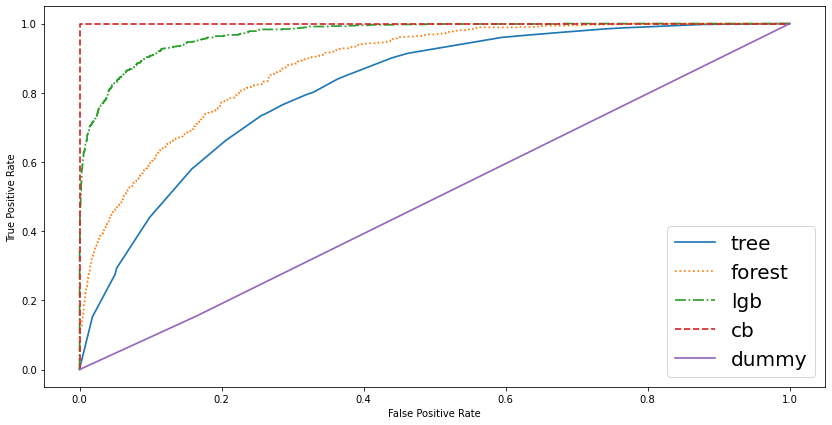

```python
def get_train_tpr_fpr(cv):
    pred_proba = cv.best_estimator_.predict_proba(X_train)[:, 1]
    fpr, tpr, _ = roc_curve(y_train, pred_proba)
    return fpr, tpr

tree_fpr, tree_tpr = get_train_tpr_fpr(rscv_tree)
forest_fpr, forest_tpr = get_train_tpr_fpr(rscv_forest)
lgb_fpr, lgb_tpr = get_train_tpr_fpr(grid_lgb)
cb_fpr, cb_tpr = get_train_tpr_fpr(grid_cb)
dummy_fpr, dummy_cpr = get_train_tpr_fpr(dummy_clf_grid)

fig, ax = plt.subplots(1, 1, figsize=(14, 7))

tree = ax.plot(tree_fpr, tree_tpr, linestyle='-', linewidth=1.7, label='tree')
forest = ax.plot(forest_fpr, forest_tpr, linestyle=':', linewidth=1.7, label='forest')
lgb = ax.plot(lgb_fpr, lgb_tpr, linestyle='-.', linewidth=1.7, label='lgb')
cb = ax.plot(cb_fpr, cb_tpr, linestyle='--', linewidth=1.7, label='cb')
dummy = ax.plot(dummy_fpr, dummy_cpr, linestyle='-', linewidth=1.7, label='dummy')

lns = tree+forest+lgb+cb+dummy
labs = [l.get_label() for l in lns]
ax.legend(lns, labs, loc=0, fontsize=20)

plt.ylabel('True Positive Rate')
plt.xlabel('False Positive Rate')
plt.show()
```

Итак, исходя из графика, мы можем сделать вывод, что дерево решений сильно переобучилось: несмотря на самую высокую среди остальных моделей метрику ROC-AUC на кросс-валидации дерево хуже всех справляется с предсказанием тренировочной выборки и имеет наименьший показатель AUC. CatBoost-модель же идеально (лучше всех) справилась с предсказанием тренировочной выборки, а значит, что данная модель обладает наилучшей обобщающей способностью среди остальных моделей, и её разброс должен быть минимальным. Учитывая всё вышесказанное, CatBoost ялвяется самым оптимальным вариантом (2-ым по cv-метрике, 1-ым по обобщению), поэтому тестировать будем именно эту модель.

## шаг. Анализ лучшей модели

Итак, проверим ROC-AUC метрику выбранной модели на тестовых данных, а также сравним её с метрикой dummy-модели.

```python
y_pred = grid_cb.predict(X_test)
y_pred_proba = grid_cb.predict_proba(X_test)[:, 1]

print(f'ROC-AUC_best_CatBoost_test_score: {round(roc_auc_score(y_test, y_pred_proba), 3)}')

print(f'ROC-AUC_best_dummy_test_score: {round(roc_auc_score(y_test, dummy_clf_grid.best_estimator_.predict_proba(X_test)[:, 1]), 3)}')
```

```
ROC-AUC_best_CatBoost_test_score: 0.898
ROC-AUC_best_dummy_test_score: 0.509
```

Отличный результат! Похоже, мы не ошиблись, выбрав именно эту модель: её разброс оказался даже отрицательным. Также мы можем считать её адекватной, учитывая тестовую метрику dummy-прогноза.

Посмотрим на важность признаков модели.

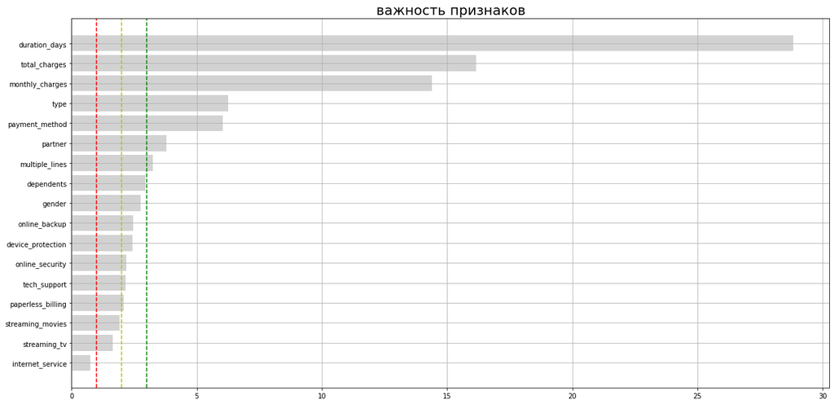

```python
importances = pd.DataFrame(data={'feature': X_train.columns,
                                 'importance': grid_cb.best_estimator_.named_steps.model.feature_importances_
                                }
                          )
importances = importances.sort_values(by='importance', ascending=True)

fig, ax = plt.subplots(1, 1, figsize=(20, 10))

plt.barh(y=importances['feature'], width=importances['importance'], color='silver', alpha=0.7)

plt.title('важность признаков', size=20)
plt.axvline(1, linestyle='--', color='r')
plt.axvline(2, linestyle='--', color='y')
plt.axvline(3, linestyle='--', color='g')

plt.grid()

plt.show()
```

Все наши количественные признаки попали в топ-3. Это косвенно подтверждает наше предположение о малом разнообразии данных. Самый полезный признак - 'duration_days', его мы выделили сами. Почти все категориальные, так называемые "услуговые" признаки оказались плюс-минус средней полезности, как мы и предположили в разделе с корреляционным анализом. Это же относится к признаку 'gender'. Самым малополезным оказался признак 'internet_service'.

Построим матрицу ошибок модели и посмотрим, как хорошо она справляется с предсказанием каждого класса непосредственно.

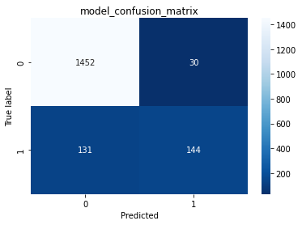

```
model_precision: 0.828
model_recall: 0.524
```

```python
cm = confusion_matrix(y_test, y_pred)
sns.heatmap(cm, annot=True, fmt='d', cmap='Blues_r')
plt.ylabel('True label')
plt.xlabel('Predicted')
plt.title('model_confusion_matrix')

plt.show()

print('model_precision: {}'.format(round(precision_score(y_test, y_pred), 3)))
print('model_recall: {}'.format(round(recall_score(y_test, y_pred), 3)))
```

Итак, у нас высокий показатель precision и низкий (средний) показатель recall. Похоже, модель чуть более чем в половине случаев правильно классифицирует клиентов, собравшихся уходить, что есть удручающий результат, особенно в нашем случае. В ТЗ сказано, что компания-заказчик хочет научиться как можно точнее заранее определять "уходильщиков" (у нас это класс '1'), чтобы предлагать им специальные условия и промокоды в целях удержания таких клиентов. Модель слишком часто ошибается в определении таких клиентов, и наверняка удержать из них получится в среднем чуть больше половины. Дело осложняется ещё тем, что, как мы выяснили, уходящие от компании клиенты в среднем ежемесячно приносят им больше прибыи. Так дело не пойдёт, поэтому попробуем поэкспериментировать с порогами классификации и "научим" нашу модель точнее определять собравшихся уходить клиентов.

Мы ориентируемся на метрику recall, поскольку компании важнее определить и удержать клиентов, собравшихся уходить, и, по идее, нестрашно, если какому-то приемлемому числу тех, кто уходить не собирался предложат промокод или спец. условия. Попробуем создать таблицу с порогами классификации и показателями метрики для тестовой выборки.

```python
rt_info = recall_threshold_table(grid_cb.best_estimator_, X_test, y_test, 0.1, 1, 10)
display(rt_info)
```

|  | порог | recall | число верно предсказанных объектов | всего объектов класса 1 |
| --- | --- | --- | --- | --- |
| 0 | y_pred_0.1 | 0.72 | 197 | 275 |
| 1 | y_pred_0.19 | 0.63 | 174 | 275 |
| 2 | y_pred_0.28 | 0.59 | 162 | 275 |
| 3 | y_pred_0.37 | 0.55 | 152 | 275 |
| 4 | y_pred_0.46 | 0.54 | 148 | 275 |
| 5 | y_pred_0.55 | 0.51 | 141 | 275 |
| 6 | y_pred_0.64 | 0.48 | 131 | 275 |
| 7 | y_pred_0.73 | 0.44 | 122 | 275 |
| 8 | y_pred_0.82 | 0.38 | 105 | 275 |
| 9 | y_pred_0.91 | 0.32 | 89 | 275 |

При пороге классификации равном 0.1 значение recall все еще относительно низко. Отмасштабируем пороговый диапазон и посмотрим, так сказать, поближе.

```python
rt_info = recall_threshold_table(grid_cb.best_estimator_, X_test, y_test, 0., 0.12, int((0.9 - 0.73) * 100))
display(rt_info)
```

[output not shown]

Самый высокий показатель recall достигается при пороге классификации равном 0.01, за исключением нуля. Такой низкий порог классификации должен сильно негативно сказаться на качестве определения моделью объектов класса 0. Попробуем построить матрицы ошибок для предсказаний модели с порогами классификации 0.01 и 0.1.

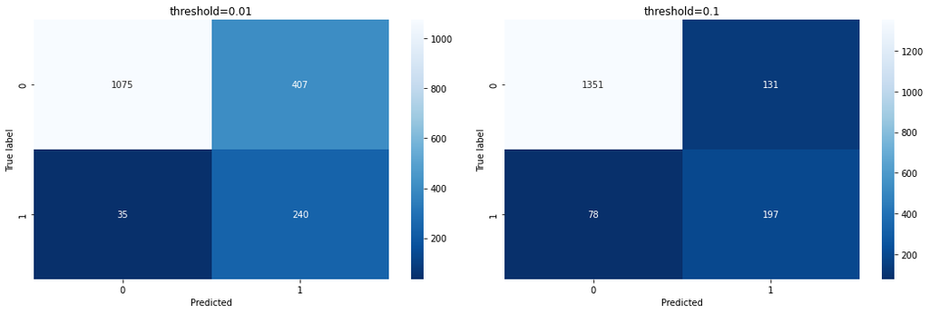

```
0.01_threshold_model_precision: 0.371
0.01_threshold_model_recall: 0.873

0.1_threshold_model_precision: 0.601
0.1_threshold_model_recall: 0.716
```

```python
def prob_by_threshold(model, X_test, y_test, threshold=0.5):
    y_proba = model.predict_proba(X_test)[:, 1]
    data = pd.DataFrame(zip(y_test, y_proba), columns=['y_valid', 'y_proba']).sort_values(by='y_proba', ascending=True)

    data['y_pred_' + str(threshold)] = data['y_proba'].apply(lambda x: 1 if x >= threshold else 0)

    return data

threshold_data_0_01 = prob_by_threshold(grid_cb.best_estimator_, X_test, y_test, 0.01)
threshold_data_01 = prob_by_threshold(grid_cb.best_estimator_, X_test, y_test, 0.1)

fig, ax = plt.subplots(1, 2, figsize=(15, 5))

cm1 = confusion_matrix(threshold_data_0_01['y_valid'], threshold_data_0_01['y_pred_0.01'])
sns.heatmap(cm1, annot=True, fmt='d', cmap='Blues_r', ax=ax[0])

ax[0].set_ylabel('True label')
ax[0].set_xlabel('Predicted')
ax[0].set_title('threshold=0.01')

cm2 = confusion_matrix(threshold_data_01['y_valid'], threshold_data_01['y_pred_0.1'])
sns.heatmap(cm2, annot=True, fmt='d', cmap='Blues_r', ax=ax[1])

ax[1].set_ylabel('True label')
ax[1].set_xlabel('Predicted')
ax[1].set_title('threshold=0.1')

fig.tight_layout()
plt.show()

print('0.01_threshold_model_precision: {}'.format(round(precision_score(threshold_data_0_01['y_valid'], threshold_data_0_01['y_pred_0.01']), 3)))
print('0.01_threshold_model_recall: {}'.format(round(recall_score(threshold_data_0_01['y_valid'], threshold_data_0_01['y_pred_0.01']), 3)))
print()
print('0.1_threshold_model_precision: {}'.format(round(precision_score(threshold_data_01['y_valid'], threshold_data_01['y_pred_0.1']), 3)))
print('0.1_threshold_model_recall: {}'.format(round(recall_score(threshold_data_01['y_valid'], threshold_data_01['y_pred_0.1']), 3)))
```

Какие выводы мы можем сделать:

1. Похоже, что даже при очень низком пороге классификации количество правильно предсказанных объектов класса '0' держится на приемлемом уровне. По всей видимости наша модель очень уверена в предсказании объектов с классом '0', то есть тех, кто не собирается уходить, чего не скажешь об объектах класса '1'.
2. При пороге классификации 0.1 правильно будут определены 197 потенциально уходящих клиентов из 275, и всего 131 неправильно определенный клиент, который уходить не собирался, из 1482. Это вполне хороший баланс, который можно считать приемлемым.
3. При пороге классификации 0.01 правильно будут определены аж 240 потенциально уходящих клиентов из 275, и уже 407 неправильно определенный клиент, который уходить не собирался, из 1482. Здесь баланс уже сильно смещен: модель становится несколько капризной при таком пороге и почти не ошибается в классе '1'. Наверное, это удовлетворительный расклад.
4. Это предварительные варианты порогов классификации, которые, тем не менее, можно считать рабочими. Точная "пороговая донастройка" требует более детального анализа клиентских платежей, прибылей и рисков и зависит от нацеленных на удержание клиентов кампаний, а также финансовых бюджетов и финансовых рисков этих кампаний: необходима консультация с отвественными лицами/отделом компании-заказчика и доп. исследование. Также можно ещё отмасштабировать пороги классификации и настроить их в разряде тысячных и даже десятитысячных.